# midterm02_stu

**Deep Learning for Mechanical Engineering**  
**Midterm Exam**  
**October 28th 2021, 8:10 PM to 10:10 PM (2 hours)**

TA: Iljeok Kim and Dogyeom Park  
Instructor: Prof. Seungchul Lee  
http://iai.postech.ac.kr/  
Industrial AI Lab at POSTECH

- I am not able to answer questions due to an online exam. I suggest you to sove the problems based on what you have here. I will try to be fair (or reasonable) on grading if any issues on problems are found afterwards.
- For your handwritten solution, scan or take a picture of them.
- For your code, only .ipynb file will be graded.
  - Please write your NAME and student ID on your .ipynb files. ex) IljeokKim_20202261_midterm.ipynb
- Please compress all the files to make a single .zip file
  - Please write your NAME and student ID on your .zip files. ex) DogyeomPark_20212049_midterm.zip
  - Submit it to PLMS
- Do not submit a printed version of your code. It will not be graded.
- Please submit your answer sheet on time. No late submission will be allowed.

# Problem 1

**Rotating Machinery Diagnosis with Logistic Regression**

Mechanical systems are always vibrating when operating. So, vibration analysis is one of the most popular and conventional ways to diagnose the mechanical system. In this problem, we are going to use the logistic regression algorithm to identify abnormality of a mechanical system.

**Data information**

- File format: npy
- Information: signal, label
- Sampling rate: 12,800 Hz
- File length (time): 0.78 sec
- Labels based on one-hot encoding
  - A (Normal): [1,0]
  - B (Abnormal): [0,1]

**Data Download Link** (same)

- [data](https://www.dropbox.com/s/3t79yd2e03fkteg/signal.npy?dl=1)
- [label](https://www.dropbox.com/s/4jr4g1sw8b38us6/label.npy?dl=1)

```python
import numpy as np
import matplotlib.pyplot as plt
import tensorflow as tf
import IPython.display as ipd
import scipy.stats
import scipy
from sklearn.model_selection import train_test_split
%matplotlib inline


# Function for reproducibility
def Random(seed_value):
    import os
    os.environ['PYTHONHASHSEED'] = str(seed_value)

    import random
    random.seed(seed_value)

    import numpy as np
    np.random.seed(seed_value)

    import tensorflow as tf
    tf.random.set_seed(seed_value)

Random(0)
```

```python
# data load
data = {
    'signal': np.load('./data_files/signal.npy'),
    'label': np.load('./data_files/label.npy')
}
```

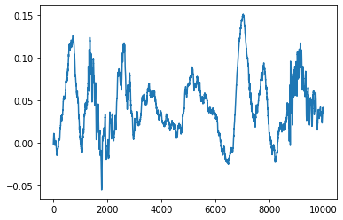

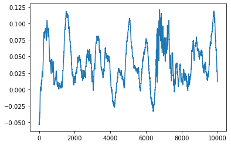

```python
N = 2000

for _ in range(2):
    i = np.random.randint(N)
    plt.plot(data['signal'][i])
    plt.show()
```

Now, we need to extract features from the raw signal.

- Use the following statistical features
  - peak, rms, kurtosis, crest factor, impulse factor, shape factor, skewness, smr, peak-peak

The equations are as follows:

$$\begin{align*} \text{Peak Value } &= \max_{n = 1, \dots, N} x_n \\ \\ \text{RMS } &= \sqrt{\frac{1}{N}\sum_{n=1}^N x_n^2} \\ \\ \text{Kurtosis } &= \frac{\frac{1}{N}\sum_{n=1}^N (x_n-\bar{x})^4}{\text{Var}^2} \\ \\ \text{Var } &= \frac{1}{N}\sum_{n=1}^N (x_n-\bar{x})^2 \\\\ \text{Crest Factor } &= \frac{\text{Peak}}{\text{RMS}}\\\\ \text{Impulse Factor } &= \frac{\text{Peak}}{\text{Mean}} \\ \\ \text{Mean } &= \frac{1}{N}\sum_{n=1}^N \lvert x_n \rvert \\\\ \text{Shape Factor } &= \frac{\text{RMS}}{\text{Mean}}\\\\ \text{Skewness } &= \frac{\frac{1}{N}\sum_{n=1}^N(x_n-\bar{x})^3}{\text{Var}^{3/2}}\\\\ \text{SMR } &= \left(\frac{1}{N}\sum_{n=1}^N\sqrt{x_n} \right)^2 \\\\ \text{Peak-Peak Value } &= \max_{n = 1, \dots, N} x_n-\min_{n = 1, \dots, N} x_n \end{align*}$$$$x_i: \text{signal data}$$

The function for feature extraction is already ready for you. The function input and output are data $x$ and horizontally stacked feature vector, respectively.

```python
def extfeat(x):
    fvector = []

    # time domain feature
    peak = np.max(np.abs(x))
    fvector.append(peak)

    rms = np.sqrt(np.mean(x**2))
    fvector.append(rms)

    kurtosis = scipy.stats.kurtosis(x)
    fvector.append(kurtosis)

    crest_factor = fvector[0]/fvector[1]
    fvector.append(crest_factor)

    impulse_factor = fvector[0]/(np.sum(np.abs(x))/len(x))
    fvector.append(impulse_factor)

    shape_factor = fvector[1]/(np.sum(np.abs(x))/len(x))
    fvector.append(shape_factor)

    skewness = scipy.stats.skew(x)
    fvector.append(skewness)

    smr = (np.sum(np.sqrt(np.abs(x)))/len(x))**2
    fvector.append(smr)

    pp = np.max(x) - np.min(x)
    fvector.append(pp)

    return fvector

feature_name = ['Peak', 'RMS', 'Kurtosis', 'Crest Factor', 'Impulse Factor','Shape Factor','Skewness','SMR', 'Peak-Peak']
```

```python
all_data = []
for i in range(len(data['label'])):
    d = extfeat(data['signal'][i])
    all_data.append(d)

all_data = np.array(all_data)

tr_data, te_data, tr_label, te_label = train_test_split(all_data, data['label'], test_size = 1/4, shuffle=True, random_state=42)
```

### 1) Design your logistic regression model using `scikit learn` library and train it. [6pt]

```python
# Your code here
```

### 2) Compute accuracy for test dataset. [5pt]

```python
# Your code here
```

### 3) Design autoencoder model with the same structure as shown in the figure below and train it. [10pt]

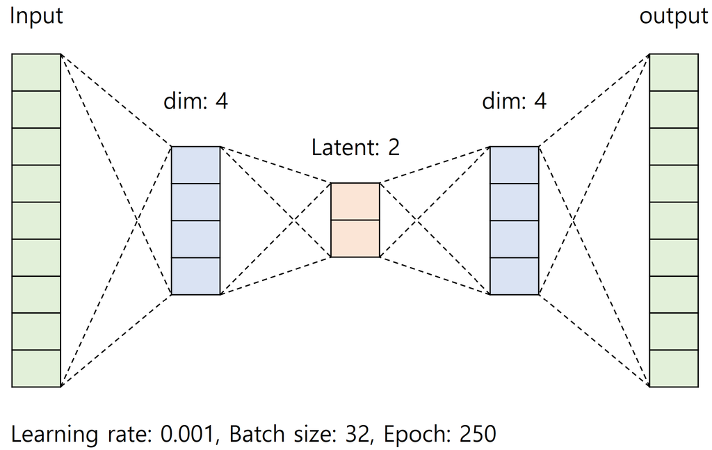

```python
# Your code here
```

### 4) Compute MSE loss for the test dataset. [5pt]

```python
# Your code here
```

### 5) Plotting latent variable for the train dataset. [8pt]

```python
# Your code here
```

### 6) Design logistic regression model to find a straight line that split normal and abnormal in the latent space. [6pt]

```python
# Your code here
```

### 7) Plotting test dataset in the latent space and straight line that split normal and abnormal. [10pt]

```python
# Your code here
```

# Problem 2

**Anomaly Detection with Autoencoder**

Mechanical systems are always making vibration during it was operated. The vibration sensor is cheap enough as well as the vibrations are different for the different operating conditions. So, vibration analysis is one of the most popular and oldest ways to diagnosis the mechanical systems. Even if vibration analysis is very popular and cheap methods, vibration analysis is very hrad for non-expert workers. Raw signals look very similar and we need to study hundreads of cases of the mechanical systems.

In this problem, we are going to detect anomalies in the mechanical system by vibration data and AI.

[figure not shown]

**Information of the Sensor Data and Anomalies:**

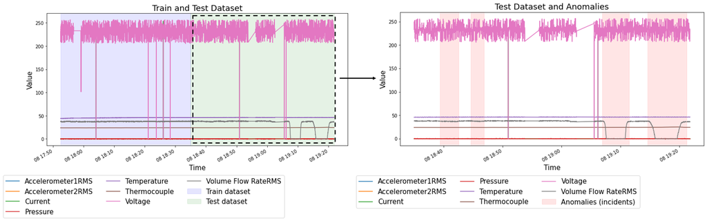

This dataset (test data) contains 4 anomalies:

- Misalignment of the pump and engine shaft (abruptly)
  - Instant defect appearing: 18:39:22
  - Instant defect disappearing: 18:42:32
- Misalignment of pump and motor shaft (slow):
  - Slow defect appearing: 18:44:36-18:45:49
  - Instant defect disappearing: 18:46:51
- Reduction of flow area section-1 (top):
  - Slow defect appearing: 19:06:57-19:07:37
  - Slow defect disappearing: 19:10:45-19:11:31
- Reduction of flow area section-2 (bottom):
  - Slow defect appearing: 19:14:40-19:16:24
  - Slow defect disappearing: 19:19:15-19:21:16

**Problem Solving Process**

1. You have to compress the information of the training data (normal) using an autoencoder.
2. Generate predicted values for train data to ensure that the autoencoder compresses the sensor data information well.
3. Predict the anomalies using the residual between the predicted value and the test data (ground truth). (Since the autoencoder learned from the train data, it will show a clear difference in the anomalies of the test data.)

```python
import pandas as pd
import numpy as np
import matplotlib.pyplot as plt

%matplotlib inline

# Function for reproducibility
def Random(seed_value):
    import os
    os.environ['PYTHONHASHSEED'] = str(seed_value)

    import random
    random.seed(seed_value)

    import numpy as np
    np.random.seed(seed_value)

    import tensorflow as tf
    tf.random.set_seed(seed_value)

Random(0)
```

- [Download data](https://www.dropbox.com/s/8ijnezkkrb3zjup/water_tank_anomaly_data.csv?dl=1) to read the files in Python.

```python
# Reading the data
# you can use either pd.DataFrame or np.array

raw_data = pd.read_csv('./data_files/water_tank_anomaly_data.csv', index_col='datetime')
data = np.array(raw_data)
```

```python
raw_data
```

| datetime | Accelerometer1RMS | Accelerometer2RMS | Current | Pressure | Temperature | Thermocouple | Voltage | Volume Flow RateRMS |
| --- | --- | --- | --- | --- | --- | --- | --- | --- |
| 2019-07-08 17:02:14 | 0.042830 | 0.080612 | 0.000749 | -0.273216 | 28.2099 | 23.4457 | 252.743 | 37.0242 |
| 2019-07-08 17:02:32 | 0.043330 | 0.084116 | 0.000849 | 0.054711 | 28.3486 | 23.4492 | 240.488 | 37.0000 |
| 2019-07-08 17:02:45 | 0.044111 | 0.082577 | 0.000764 | 0.054711 | 28.6534 | 23.4417 | 235.642 | 37.9764 |
| 2019-07-08 17:02:46 | 0.044244 | 0.079906 | 0.000914 | -0.273216 | 28.8157 | 23.4417 | 229.536 | 37.0242 |
| 2019-07-08 17:02:47 | 0.042298 | 0.081938 | 0.000768 | 0.054711 | 28.3558 | 23.4362 | 239.926 | 37.9764 |
| ... | ... | ... | ... | ... | ... | ... | ... | ... |
| 2019-07-08 19:21:47 | 0.036152 | 0.063038 | 0.000471 | -0.273216 | 46.0023 | 24.3395 | 220.734 | 36.0000 |
| 2019-07-08 19:21:48 | 0.035053 | 0.063914 | 0.000758 | 0.054711 | 46.3134 | 24.3407 | 207.956 | 36.0334 |
| 2019-07-08 19:21:49 | 0.035560 | 0.064118 | 0.000949 | 0.054711 | 46.3939 | 24.3303 | 234.686 | 36.9675 |
| 2019-07-08 19:21:50 | 0.035372 | 0.063209 | 0.000978 | -0.273216 | 46.2248 | 24.3337 | 212.592 | 36.0000 |
| 2019-07-08 19:21:51 | 0.035453 | 0.060877 | 0.000980 | -0.601143 | 46.2927 | 24.3337 | 232.498 | 36.0334 |

6405 rows × 8 columns

### (1) Plot each sensor data to understand the distribution of each sensor data. [5 pt]

```python
# Plotting separate pictures for signals
```

### (2) Data Preprocessing

**(2-1) Split the data into train and test dataset. [5 pt]**

- Training sample — Data for learning and optimizing model parameters
- Test sample — Data to evaluate the performance of the model.

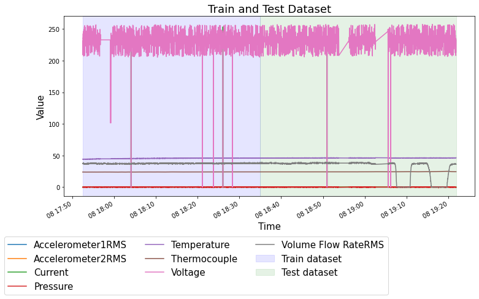

**(2-2) Make two train and test dataset with/without normalization. [5 pt]**

- As shown in the image above, normalization should be performed because the unit for each sensor is different. (For example, the voltage value ranges from 0 to about 250, and the volume flow is from 0 to about 40.)
- For the normalized dataset, normalize each sensor with the minimum value of 0 and the maximum value of 1. (Learn the scale of training data using `MinMax.fit` and transform the training data and validation data using `MinMax.transform`)

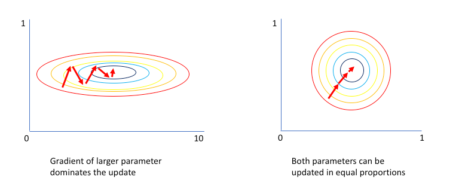

```python
from sklearn.preprocessing import MinMaxScaler

# all data length: 6405
# train dataset: 0 ~ 4000, test dataset: 4001 ~ end

MinMax = MinMaxScaler()

# Your code here
```

### (3) Construct the Autoencoder Model.

**(3-1) Construct the Autoencoder Model. [10 pt]**

- Build 2 training models using training data w/wo normalization.

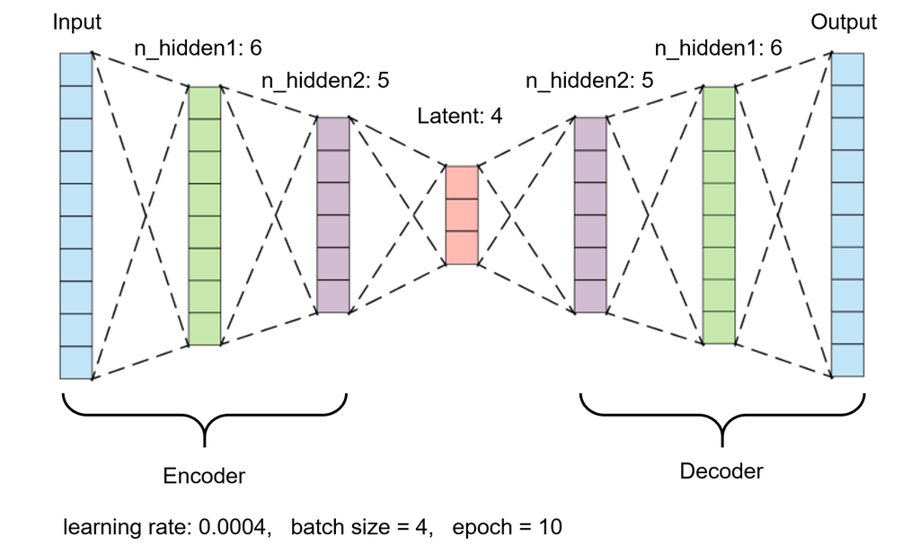

```python
# Your code here
# Deep learning architecture
```

```python
# Your code here
# Non-normalized model training
```

```python
# Your code here
# Normalized model training
```

**(3-2) Compare the mean squared error of the two models. [5 pt]**

```python
# Your code here
```

[output not shown]

### (4) Plot the Loss Graph in the Training Process for the Two Models. [5 pt]

- To check the normalized model, set the y_lim of the left figure from 0 to 20.

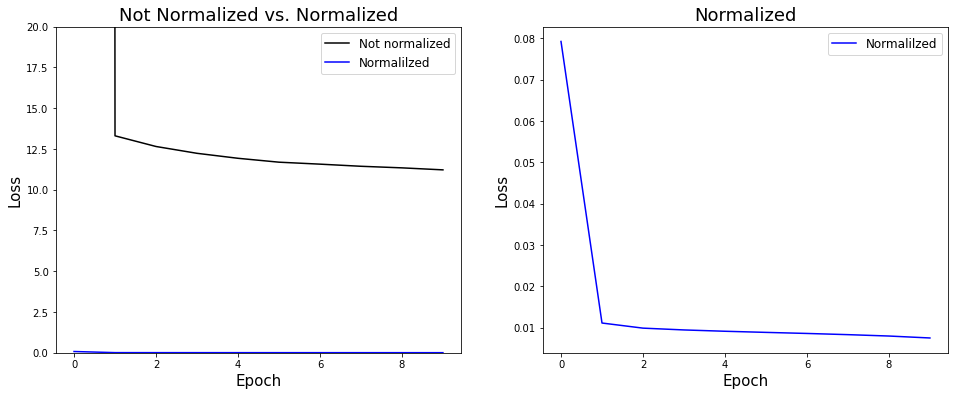

```python
# Your code here
```

### (5) Plot the Autoencoder's Predicted Values for the Train Dataset and the Actual Train Values (Ground Truth). [5 pt]

**Non-normalized Training Data Model**

```python
# Your code here
```

**Normalized Training Data Model**

- Use `MinMax.inverse_transform` to transform normalized data to its original dimensions.

```python
# Your coder here
```

### (6) Anomaly Detection

**(6-1) Plot the residual graph. [5pt]**

- Predict the results using the normalized test dataset and plot the residual.
- The residual = normalized test data - predicted values of normalized test data.

```python
# Your code here
```

**(6-2) Plot the Health Indicator. [5 pt]**

- Health indicator = sum of the residuals.
- Plot a graph for the health indicator value of the machine.
- Check that the 4 anomalies are correctly detected. The position of the anomalies is roughly correct without the need for exact confirmation.

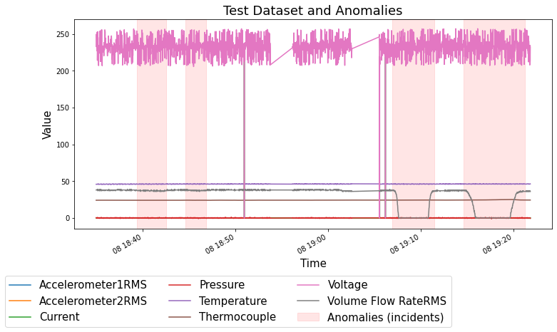

```python
# Your code here
```